# Effect for Those Who Have Received Coupon in FY2019 (Sample Selection 2)

Preview

Hiroki Kato

2022-03-12

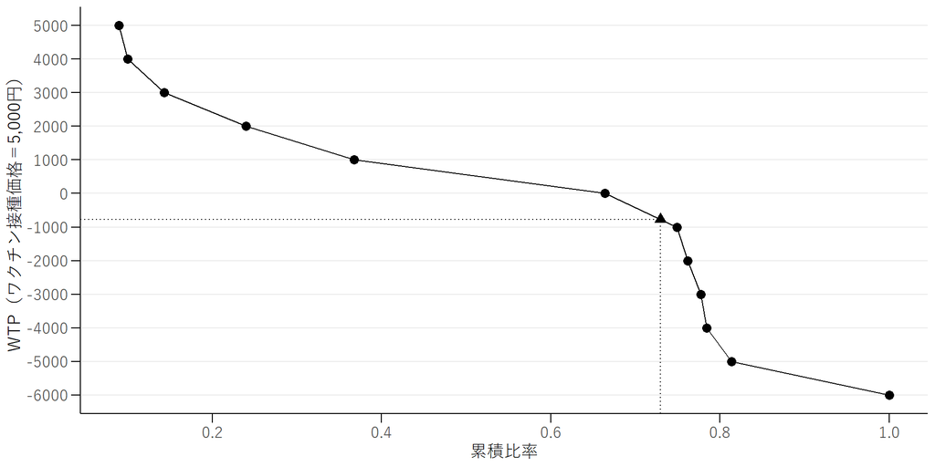

2019年度クーポン券配布対象者の風しんワクチンの需要曲線。データソース：Wave 2データ。注）黒の三角はワクチン接種費用が無料であるときの接種割合と厚労省メッセージの抗体検査受検率を合計した割合と、それに対応するWTPを示している。

ナッジ・メッセージの金銭的価値の推定

| ナッジ・メッセージ | 効果の規模 | ベースライン＋効果の規模 | 金銭的価値（日本円） 一人当たり | 金銭的価値（日本円） 総額 | 金銭的価値（米ドル） 一人当たり | 金銭的価値（米ドル） 総額 |
| --- | --- | --- | --- | --- | --- | --- |
| 年齢表現 | 0.037 | 0.766 | 1528.377 | 8.085 | 13.894 | 73.501 |
| 利他強調 | 0.075 | 0.805 | 3925.285 | 20.765 | 35.684 | 188.771 |
| 利己強調 | 0.056 | 0.786 | 3285.074 | 17.378 | 29.864 | 157.982 |
| 社会比較 | 0.047 | 0.777 | 2200.534 | 11.641 | 20.005 | 105.826 |
| 有効期限 | 0.034 | 0.763 | 1331.690 | 7.045 | 12.106 | 64.042 |
| 低コスト | 0.034 | 0.763 | 1327.720 | 7.024 | 12.070 | 63.851 |

注） 抗体検査の受検に対するナッジ・メッセージの効果を効果の規模として用いた。 ベースラインはワクチン接種費用が無料であるときの接種割合と 厚労省メッセージの抗体検査受検率を合計した割合である。 金銭的価値は一人当たりの価値と それに2020年1月時点でワクチンクーポン券を利用していない人数（529万人）をかけた 総額を示している。 また、金銭的価値は日本円と米ドルで示した（1ドル＝110円）。 一人当たりの金銭的価値の単位はそれぞれ1円と1ドルである。 総額で示した金銭的価値の単位はそれぞれ10億円と100万ドルである。